# Data Science Linear Regression

The textbook for the Data Science course series is [freely available online](https://rafalab.github.io/dsbook/).

# Learning Objectives

- How linear regression was originally developed by Galton
- What confounding is and how to detect it
- How to examine the relationships between variables by implementing linear regression in R

## Course Overview

There are three major sections in this course: introduction to linear regression, linear models, and confounding.

### Introduction to Linear Regression

In this section, you’ll learn the basics of linear regression through this course’s motivating example, the data-driven approach used to construct baseball teams. You’ll also learn about correlation, the correlation coefficient, stratification, and the variance explained.

### Linear Models

In this section, you’ll learn about linear models. You’ll learn about least squares estimates, multivariate regression, and several useful features of R, such as tibbles, lm, do, and broom. You’ll learn how to apply regression to baseball to build a better offensive metric.

### Confounding

In the final section of the course, you’ll learn about confounding and several reasons that correlation is not the same as causation, such as spurious correlation, outliers, reversing cause and effect, and confounders. You’ll also learn about Simpson’s Paradox.

## Introduction to Regression Overview

In the **Introduction to Regression** section, you will learn the basics of linear regression.

After completing this section, you will be able to:

- Understand how Galton developed **linear regression**.
- Calculate and interpret the **sample correlation**.
- **Stratify** a dataset when appropriate.
- Understand what a **bivariate normal distribution** is.
- Explain what the term **variance explained** means.
- Interpret the two **regression lines**.

This section has three parts: **Baseball as a Motivating Example**, **Correlation**, and **Stratification and Variance Explained**.

## Motivating Example: Moneyball

The corresponding section of the textbook is the [case study on Moneyball](https://rafalab.github.io/dsbook/linear-models.html#case-study-moneyball)

**Key points**

Bill James was the originator of the **sabermetrics**, the approach of using data to predict what outcomes best predicted if a team would win.

## Baseball basics

The corresponding section of the textbook is the [section on baseball basics](https://rafalab.github.io/dsbook/linear-models.html#baseball-basics)

**Key points**

- The goal of a baseball game is to score more runs (points) than the other team.
- Each team has 9 batters who have an opportunity to hit a ball with a bat in a predetermined order.
- Each time a batter has an opportunity to bat, we call it a plate appearance (PA).
- The PA ends with a binary outcome: the batter either makes an out (failure) and returns to the bench or the batter doesn’t (success) and can run around the bases, and potentially score a run (reach all 4 bases).
- We are simplifying a bit, but there are five ways a batter can succeed (not make an out):
1. Bases on balls (BB): the pitcher fails to throw the ball through a predefined area considered to be hittable (the strike zone), so the batter is permitted to go to first base.
2. Single: the batter hits the ball and gets to first base.
3. Double (2B): the batter hits the ball and gets to second base.
4. Triple (3B): the batter hits the ball and gets to third base.
5. Home Run (HR): the batter hits the ball and goes all the way home and scores a run.
- Historically, the batting average has been considered the most important offensive statistic. To define this average, we define a hit (H) and an at bat (AB). Singles, doubles, triples and home runs are hits. The fifth way to be successful, a walk (BB), is not a hit. An AB is the number of times you either get a hit or make an out; BBs are excluded. The batting average is simply H/AB and is considered the main measure of a success rate.

## Bases on Balls or Stolen Bases?

The corresponding section of the textbook is the [base on balls or stolen bases textbook section](https://rafalab.github.io/dsbook/linear-models.html#base-on-balls-or-stolen-bases)

**Key points**

The visualization of choice when exploring the relationship between two variables like home runs and runs is a scatterplot.

*Code: Scatterplot of the relationship between HRs and runs*

```r
if(!require(Lahman)) install.packages("Lahman")
if(!require(tidyverse)) install.packages("tidyverse")
if(!require(dslabs)) install.packages("dslabs")
```

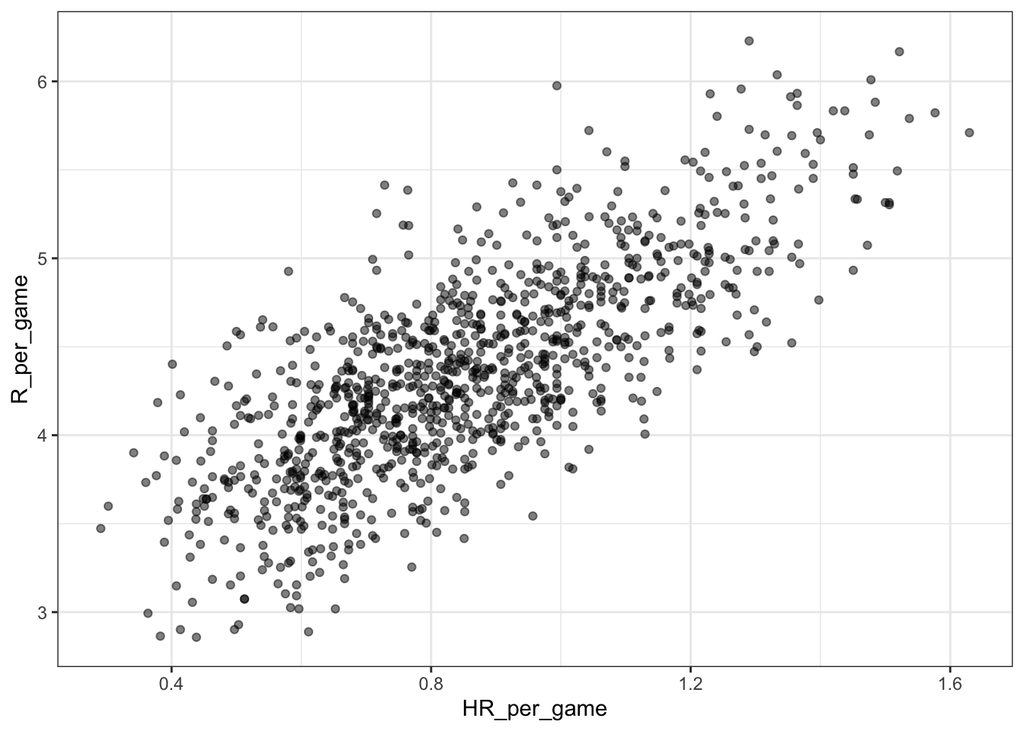

```r
library(Lahman)
library(tidyverse)
library(dslabs)
ds_theme_set()

Teams %>% filter(yearID %in% 1961:2001) %>%
    mutate(HR_per_game = HR / G, R_per_game = R / G) %>%
    ggplot(aes(HR_per_game, R_per_game)) +
    geom_point(alpha = 0.5)
```

*Code: Scatterplot of the relationship between stolen bases and runs*

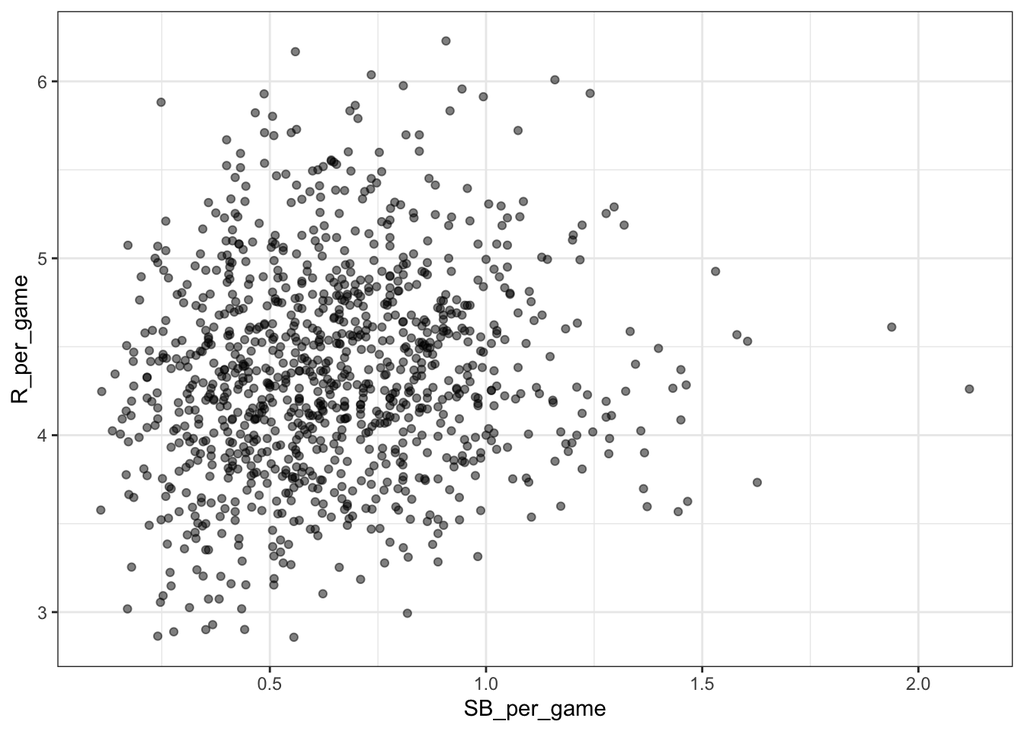

```r
Teams %>% filter(yearID %in% 1961:2001) %>%
    mutate(SB_per_game = SB / G, R_per_game = R / G) %>%
    ggplot(aes(SB_per_game, R_per_game)) +
    geom_point(alpha = 0.5)
```

*Code: Scatterplot of the relationship between bases on balls and runs*

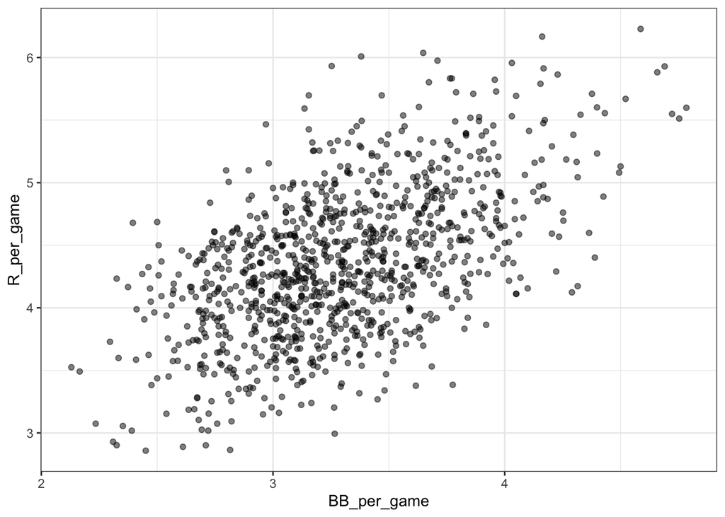

```r
Teams %>% filter(yearID %in% 1961:2001) %>%
    mutate(BB_per_game = BB / G, R_per_game = R / G) %>%
    ggplot(aes(BB_per_game, R_per_game)) +
    geom_point(alpha = 0.5)
```

## Assessment - Baseball as a Motivating Example

1. What is the application of statistics and data science to baseball called?
- A. Moneyball
- B. Sabermetrics
- C. The “Oakland A’s Approach”
- D. There is no specific name for this; it’s just data science.
2. Which of the following outcomes is not included in the batting average?
- A. A home run
- B. A base on balls
- C. An out
- D. A single
3. Why do we consider team statistics as well as individual player statistics?
- A. The success of any individual player also depends on the strength of their team.
- B. Team statistics can be easier to calculate.
- C. The ultimate goal of sabermetrics is to rank teams, not players.
4. You want to know whether teams with more at-bats per game have more runs per game. What R code below correctly makes a scatter plot for this relationship?

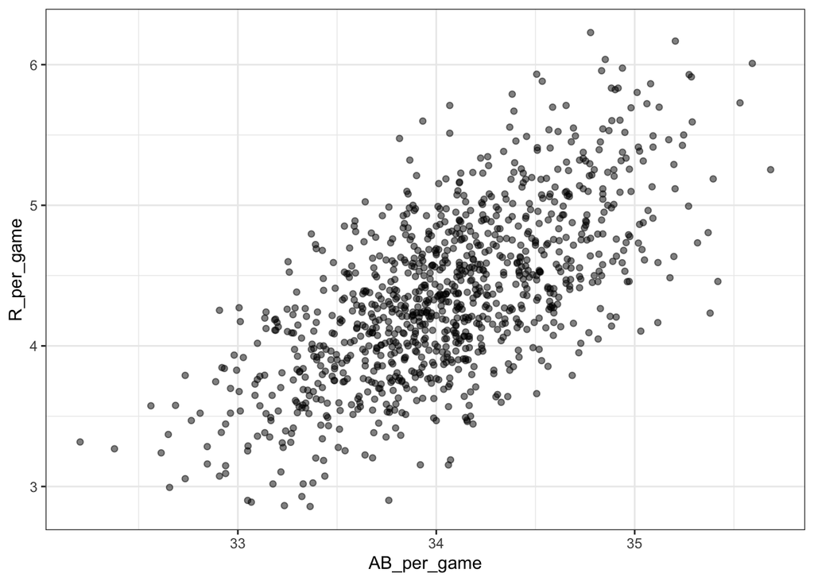

```r
Teams %>% filter(yearID %in% 1961:2001 ) %>%
    mutate(AB_per_game = AB/G, R_per_game = R/G) %>%
    ggplot(aes(AB_per_game, R_per_game)) +
    geom_point(alpha = 0.5)
```

- A.

```r
Teams %>% filter(yearID %in% 1961:2001 ) %>%
    ggplot(aes(AB, R)) +
    geom_point(alpha = 0.5)
```

- B.

```r
Teams %>% filter(yearID %in% 1961:2001 ) %>%
    mutate(AB_per_game = AB/G, R_per_game = R/G) %>%
    ggplot(aes(AB_per_game, R_per_game)) +
    geom_point(alpha = 0.5)
```

- C.

```r
Teams %>% filter(yearID %in% 1961:2001 ) %>%
    mutate(AB_per_game = AB/G, R_per_game = R/G) %>%
    ggplot(aes(AB_per_game, R_per_game)) +
    geom_line()
```

- D.

```r
Teams %>% filter(yearID %in% 1961:2001 ) %>%
    mutate(AB_per_game = AB/G, R_per_game = R/G) %>%
    ggplot(aes(R_per_game, AB_per_game)) +
    geom_point()
```

5. What does the variable “SOA” stand for in the Teams table?

Hint: make sure to use the help file (`?Teams`).

- A. sacrifice out
- B. slides or attempts
- C. strikeouts by pitchers
- D. accumulated singles
6. Load the **Lahman** library. Filter the `Teams` data frame to include years from 1961 to 2001. Make a scatterplot of runs per game versus at bats (`AB`) per game.

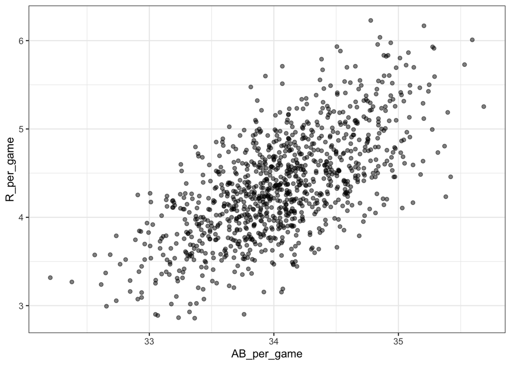

```r
Teams %>% filter(yearID %in% 1961:2001) %>%
  mutate(AB_per_game = AB / G, R_per_game = R / G) %>%
  ggplot(aes(AB_per_game, R_per_game)) +
  geom_point(alpha = 0.5)
```

Which of the following is true?

- A. There is no clear relationship between runs and at bats per game.
- B. As the number of at bats per game increases, the number of runs per game tends to increase.
- C. As the number of at bats per game increases, the number of runs per game tends to decrease.
7. Use the filtered `Teams` data frame from Question 6. Make a scatterplot of win rate (number of wins per game) versus number of fielding errors (`E`) per game.

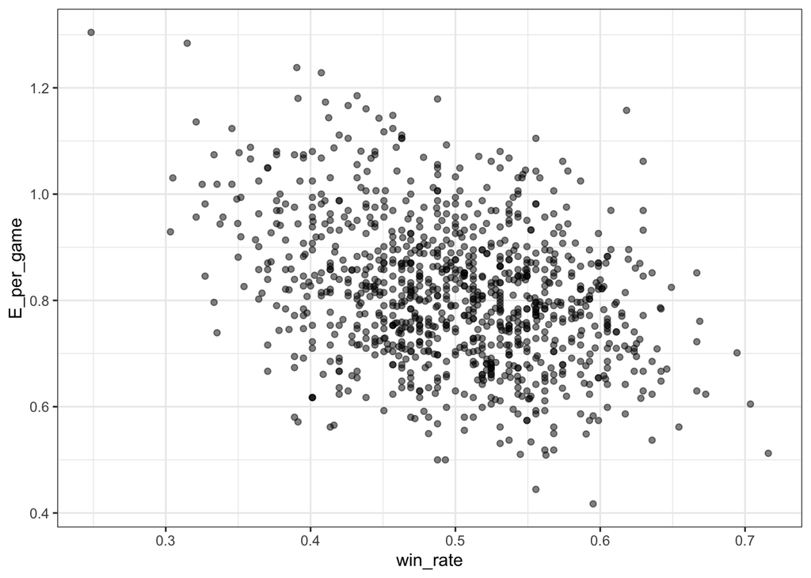

```r
Teams %>% filter(yearID %in% 1961:2001) %>%
  mutate(win_rate = W / G, E_per_game = E / G) %>%
  ggplot(aes(win_rate, E_per_game)) +
  geom_point(alpha = 0.5)
```

Which of the following is true?

- A. There is no relationship between win rate and errors per game.
- B. As the number of errors per game increases, the win rate tends to increase.
- C. As the number of errors per game increases, the win rate tends to decrease.
8. Use the filtered `Teams` data frame from Question 6. Make a scatterplot of triples (`X3B`) per game versus doubles (`X2B`) per game.

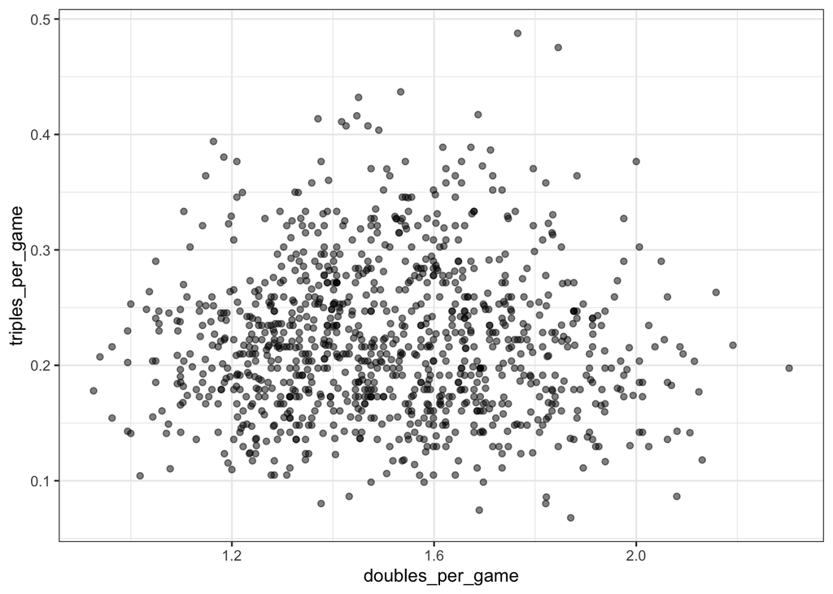

```r
Teams %>% filter(yearID %in% 1961:2001) %>%
  mutate(doubles_per_game = X2B / G, triples_per_game = X3B / G) %>%
  ggplot(aes(doubles_per_game, triples_per_game)) +
  geom_point(alpha = 0.5)
```

Which of the following is true?

- A. There is no clear relationship between doubles per game and triples per game.
- B. As the number of doubles per game increases, the number of triples per game tends to increase.
- C. As the number of doubles per game increases, the number of triples per game tends to decrease.

## Correlation

The corresponding textbook section is [Case Study: is height hereditary?](https://rafalab.github.io/dsbook/regression.html#case-study-is-height-hereditary)

**Key points**

- Galton tried to predict sons’ heights based on fathers’ heights.
- The mean and standard errors are insufficient for describing an important characteristic of the data: the trend that the taller the father, the taller the son.
- The correlation coefficient is an informative summary of how two variables move together that can be used to predict one variable using the other.

*Code*

```r
# create the dataset
if(!require(HistData)) install.packages("HistData")
library(tidyverse)
library(HistData)
data("GaltonFamilies")
set.seed(1983)
galton_heights <- GaltonFamilies %>%
  filter(gender == "male") %>%
  group_by(family) %>%
  sample_n(1) %>%
  ungroup() %>%
  select(father, childHeight) %>%
  rename(son = childHeight)

# means and standard deviations
galton_heights %>%
    summarize(mean(father), sd(father), mean(son), sd(son))
```

```
## # A tibble: 1 x 4
##   `mean(father)` `sd(father)` `mean(son)` `sd(son)`
##            <dbl>        <dbl>       <dbl>     <dbl>
## 1           69.1         2.55        69.2      2.71
```

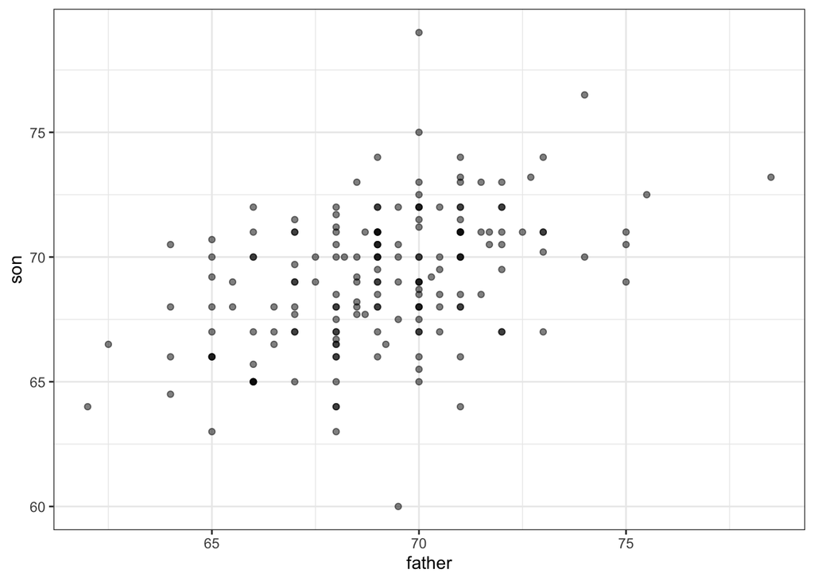

```r
# scatterplot of father and son heights
galton_heights %>%
    ggplot(aes(father, son)) +
    geom_point(alpha = 0.5)
```

## Correlation Coefficient

The corresponding textbook section is [the correlation coefficient](https://rafalab.github.io/dsbook/regression.html#corr-coef)

**Key points**

*Code*

```r
rho <- mean(scale(x)*scale(y))
```

```r
data("GaltonFamilies")
galton_heights <- GaltonFamilies %>% filter(childNum == 1 & gender == "male") %>% select(father, childHeight) %>% rename(son = childHeight)
galton_heights %>% summarize(r = cor(father, son)) %>% pull(r)
```

```
## [1] 0.5007248
```

## Sample Correlation is a Random Variable

The corresponding textbook section is [Sample correlation is a random variable](https://rafalab.github.io/dsbook/regression.html#sample-correlation-is-a-random-variable)

**Key points**

- The correlation that we compute and use as a summary is a random variable.
- When interpreting correlations, it is important to remember that correlations derived from samples are estimates containing uncertainty.
- Because the sample correlation is an average of independent draws, the central limit theorem applies.

*Code*

```r
# compute sample correlation
R <- sample_n(galton_heights, 25, replace = TRUE) %>%
    summarize(r = cor(father, son))
R
```

```
##           r
## 1 0.4787613
```

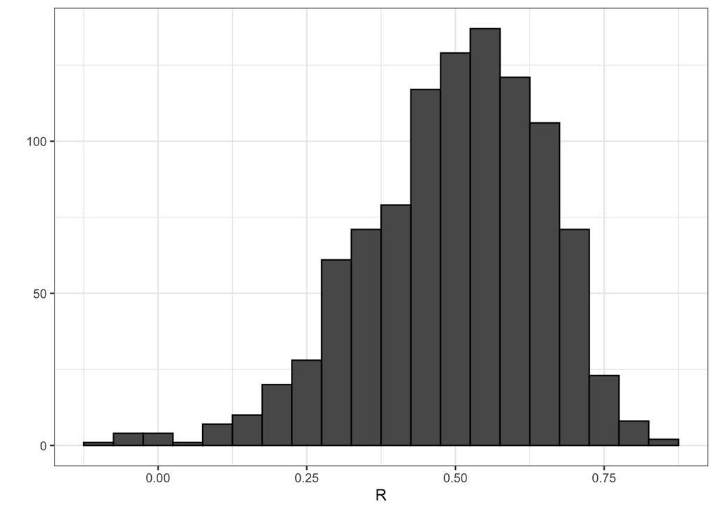

```r
# Monte Carlo simulation to show distribution of sample correlation
B <- 1000
N <- 25
R <- replicate(B, {
    sample_n(galton_heights, N, replace = TRUE) %>%
    summarize(r = cor(father, son)) %>%
    pull(r)
})
qplot(R, geom = "histogram", binwidth = 0.05, color = I("black"))
```

```r
# expected value and standard error
mean(R)
```

```
## [1] 0.4970997
```

```r
sd(R)
```

```
## [1] 0.1512451
```

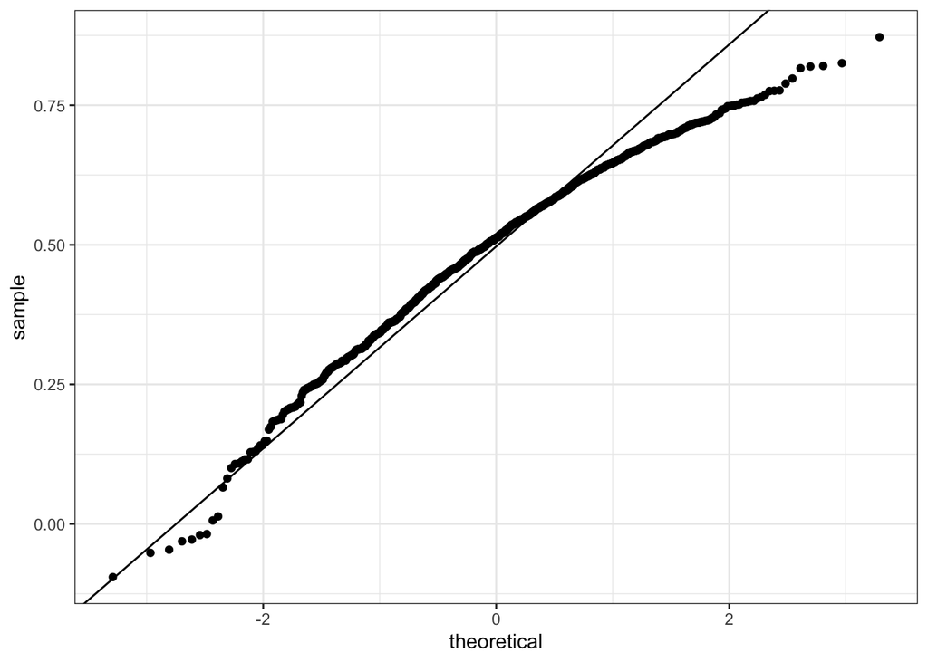

```r
# QQ-plot to evaluate whether N is large enough
data.frame(R) %>%
    ggplot(aes(sample = R)) +
    stat_qq() +
    geom_abline(intercept = mean(R), slope = sqrt((1-mean(R)^2)/(N-2)))
```

## Assessment - Correlation

1. While studying heredity, Francis Galton developed what important statistical concept?
- A. Standard deviation
- B. Normal distribution
- C. Correlation
- D. Probability
2. The correlation coefficient is a summary of what?
- A. The trend between two variables
- B. The dispersion of a variable
- C. The central tendency of a variable
- D. The distribution of a variable
3. Below is a scatter plot showing the relationship between two variables, x and y.

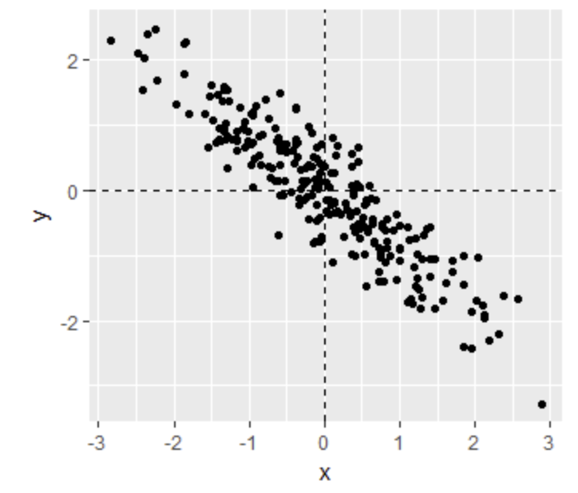

Scatter plot relationship x and y

From this figure, the correlation between x and y appears to be about:

- A. -0.9
- B. -0.2
- C. 0.9
- D. 2
4. Instead of running a Monte Carlo simulation with a sample size of 25 from our 179 father-son pairs, we now run our simulation with a sample size of 50.

Would you expect the **mean** of our sample correlation to increase, decrease, or stay approximately the same?

- A. Increase
- B. Decrease
- C. Stay approximately the same
5. Instead of running a Monte Carlo simulation with a sample size of 25 from our 179 father-son pairs, we now run our simulation with a sample size of 50.

Would you expect the **standard deviation** of our sample correlation to increase, decrease, or stay approximately the same?

- A. Increase
- B. Decrease
- C. Stay approximately the same
6. If X and Y are completely independent, what do you expect the value of the correlation coefficient to be?
- A. -1
- B. -0.5
- C. 0
- D. 0.5
- E. 1
- F. Not enough information to answer the question
7. Load the **Lahman** library. Filter the `Teams` data frame to include years from 1961 to 2001.

What is the correlation coefficient between number of runs per game and number of at bats per game?

## Assessment - Stratification and Variance Explained, Part 1

1. Look at the figure below. The slope of the regression line in this figure is equal to what, in words?

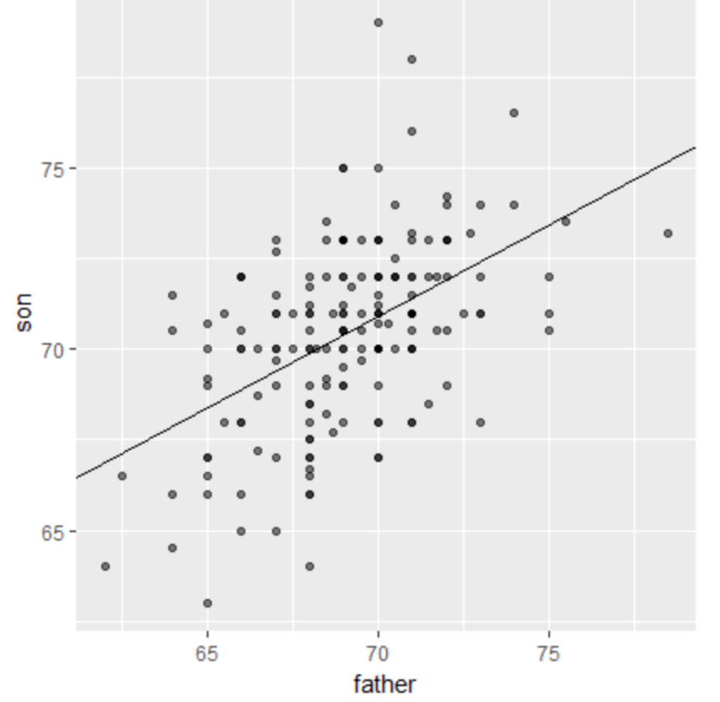

Scatter plot of son and father heights with son heights on the y-axis and father heights on the x-axis

- A. Slope = (correlation coefficient of son and father heights) * (standard deviation of sons’ heights / standard deviation of fathers’ heights)
- B. Slope = (correlation coefficient of son and father heights) * (standard deviation of fathers’ heights / standard deviation of sons’ heights)
- C. Slope = (correlation coefficient of son and father heights) / (standard deviation of sons’ heights * standard deviation of fathers’ heights)
- D. Slope = (mean height of fathers) - (correlation coefficient of son and father heights * mean height of sons).
2. Why does the regression line simplify to a line with intercept zero and slope when we standardize our x and y variables? Try the simplification on your own first!
- A. When we standardize variables, both x and y will have a mean of one and a standard deviation of zero. When you substitute this into the formula for the regression line, the terms cancel out until we have the following equation: $y_i=px_i$.
- B. When we standardize variables, both x and y will have a mean of zero and a standard deviation of one. When you substitute this into the formula for the regression line, the terms cancel out until we have the following equation: $y_i = px_i$.
- C. When we standardize variables, both x and y will have a mean of zero and a standard deviation of one. When you substitute this into the formula for the regression line, the terms cancel out until we have the following equation: $y_i=px_i$.
3. What is a limitation of calculating conditional means?
- A. Each stratum we condition on (e.g., a specific father’s height) may not have many data points.
- B. Because there are limited data points for each stratum, our average values have large standard errors.
- C. Conditional means are less stable than a regression line.
- D. Conditional means are a useful theoretical tool but cannot be calculated.

## Assessment 8 - Bivariate Normal Distribution

1. A regression line is the best prediction of Y given we know the value of X when:
- A. X and Y follow a bivariate normal distribution.
- B. Both X and Y are normally distributed.
- C. Both X and Y have been standardized.
- D. There are at least 25 X-Y pairs.
2. Which one of the following scatterplots depicts an x and y distribution that is NOT well-approximated by the bivariate normal distribution?
- A.

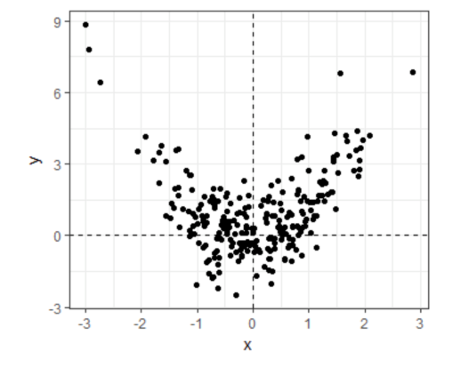

Scatter plot A

- B.

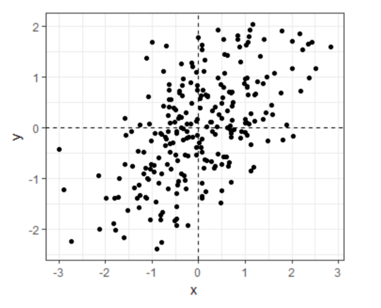

Scatter plot B

- C.

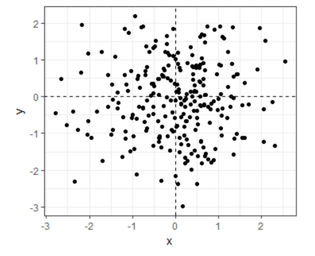

Scatter plot C

- D.

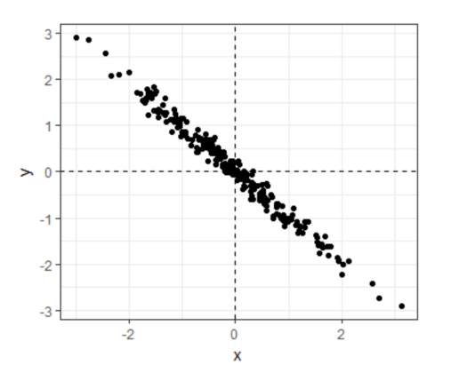

Scatter plot D

## Assessment 9 - Variance Explained

1. We previously calculated that the correlation coefficient between fathers’ and sons’ heights is 0.5.

Given this, what percent of the variation in sons’ heights is explained by fathers’ heights?

- A. 0%
- B. 25%
- C. 50%
- D. 75%

## Linear Models Overview

In the Linear Models section, you will learn how to do linear regression.

After completing this section, you will be able to:

- Use multivariate regression to adjust for confounders.
- Write linear models to describe the relationship between two or more variables.
- Calculate the least squares estimates for a regression model using the lm function.
- Understand the differences between tibbles and data frames.
- Use the do function to bridge R functions and the tidyverse.
- Use the tidy, glance, and augment functions from the broom package.
- Apply linear regression to measurement error models.

This section has four parts: Introduction to Linear Models, Least Squares Estimates, Tibbles, do, and broom, and Regression and Baseball.

The textbook for this section is available [here](https://rafalab.github.io/dsbook/linear-models.html#confounding)

## Assessment 1 - Confounding: Are BBs More Predictive?

1. Why is the number of home runs considered a confounder of the relationship between bases on balls and runs per game?
- A. Home runs is not a confounder of this relationship.
- B. Home runs are the primary cause of runs per game.
- C. The correlation between home runs and runs per game is stronger than the correlation between bases on balls and runs per game.
- D. Players who get more bases on balls also tend to have more home runs; in addition, home runs increase the points per game.